# White wine quality exploration by Chomnoue Nghemning Alain-Michel

## Which chemical properties influence the quality of white wines?

```r
library(ggplot2)
library(GGally)
library(memisc)
library(gridExtra)
theme_set(theme_classic(12))
```

# Analysis

### Load the Data

```r
#I ignore the first (no name) column of the csv file
#it is used just to number the lines in the file, so it is useless for the analysis
wines=read.csv('wineQualityWhites.csv')[,c(2:13)]
```

### Summary of the Data Set

```r
dim(wines)
```

```
## [1] 4898   12
```

```r
names(wines)
```

```
##  [1] "fixed.acidity"        "volatile.acidity"     "citric.acid"
##  [4] "residual.sugar"       "chlorides"            "free.sulfur.dioxide"
##  [7] "total.sulfur.dioxide" "density"              "pH"
## [10] "sulphates"            "alcohol"              "quality"
```

```r
str(wines)
```

```
## 'data.frame':    4898 obs. of  12 variables:
##  $ fixed.acidity       : num  7 6.3 8.1 7.2 7.2 8.1 6.2 7 6.3 8.1 ...
##  $ volatile.acidity    : num  0.27 0.3 0.28 0.23 0.23 0.28 0.32 0.27 0.3 0.22 ...
##  $ citric.acid         : num  0.36 0.34 0.4 0.32 0.32 0.4 0.16 0.36 0.34 0.43 ...
##  $ residual.sugar      : num  20.7 1.6 6.9 8.5 8.5 6.9 7 20.7 1.6 1.5 ...
##  $ chlorides           : num  0.045 0.049 0.05 0.058 0.058 0.05 0.045 0.045 0.049 0.044 ...
##  $ free.sulfur.dioxide : num  45 14 30 47 47 30 30 45 14 28 ...
##  $ total.sulfur.dioxide: num  170 132 97 186 186 97 136 170 132 129 ...
##  $ density             : num  1.001 0.994 0.995 0.996 0.996 ...
##  $ pH                  : num  3 3.3 3.26 3.19 3.19 3.26 3.18 3 3.3 3.22 ...
##  $ sulphates           : num  0.45 0.49 0.44 0.4 0.4 0.44 0.47 0.45 0.49 0.45 ...
##  $ alcohol             : num  8.8 9.5 10.1 9.9 9.9 10.1 9.6 8.8 9.5 11 ...
##  $ quality             : int  6 6 6 6 6 6 6 6 6 6 ...
```

```r
summary(wines)
```

```
##  fixed.acidity    volatile.acidity  citric.acid     residual.sugar
##  Min.   : 3.800   Min.   :0.0800   Min.   :0.0000   Min.   : 0.600
##  1st Qu.: 6.300   1st Qu.:0.2100   1st Qu.:0.2700   1st Qu.: 1.700
##  Median : 6.800   Median :0.2600   Median :0.3200   Median : 5.200
##  Mean   : 6.855   Mean   :0.2782   Mean   :0.3342   Mean   : 6.391
##  3rd Qu.: 7.300   3rd Qu.:0.3200   3rd Qu.:0.3900   3rd Qu.: 9.900
##  Max.   :14.200   Max.   :1.1000   Max.   :1.6600   Max.   :65.800
##    chlorides       free.sulfur.dioxide total.sulfur.dioxide
##  Min.   :0.00900   Min.   :  2.00      Min.   :  9.0
##  1st Qu.:0.03600   1st Qu.: 23.00      1st Qu.:108.0
##  Median :0.04300   Median : 34.00      Median :134.0
##  Mean   :0.04577   Mean   : 35.31      Mean   :138.4
##  3rd Qu.:0.05000   3rd Qu.: 46.00      3rd Qu.:167.0
##  Max.   :0.34600   Max.   :289.00      Max.   :440.0
##     density             pH          sulphates         alcohol
##  Min.   :0.9871   Min.   :2.720   Min.   :0.2200   Min.   : 8.00
##  1st Qu.:0.9917   1st Qu.:3.090   1st Qu.:0.4100   1st Qu.: 9.50
##  Median :0.9937   Median :3.180   Median :0.4700   Median :10.40
##  Mean   :0.9940   Mean   :3.188   Mean   :0.4898   Mean   :10.51
##  3rd Qu.:0.9961   3rd Qu.:3.280   3rd Qu.:0.5500   3rd Qu.:11.40
##  Max.   :1.0390   Max.   :3.820   Max.   :1.0800   Max.   :14.20
##     quality
##  Min.   :3.000
##  1st Qu.:5.000
##  Median :6.000
##  Mean   :5.878
##  3rd Qu.:6.000
##  Max.   :9.000
```

##### Observations from the summary

The number of variables, the number of attributes and their names correspond to the description in the wineQualityInfo.txt file.

All attributes are decimals except the output variable (quality) which is of type integer.

Most of the attrbutes (except density, PH, alcohol and quality) have a Max value near twice (or greater) the third quantile. Let us plot them to see more.

### Understanding the distribution of single variables

Let us explore individual variables first

#### Fixed acidity

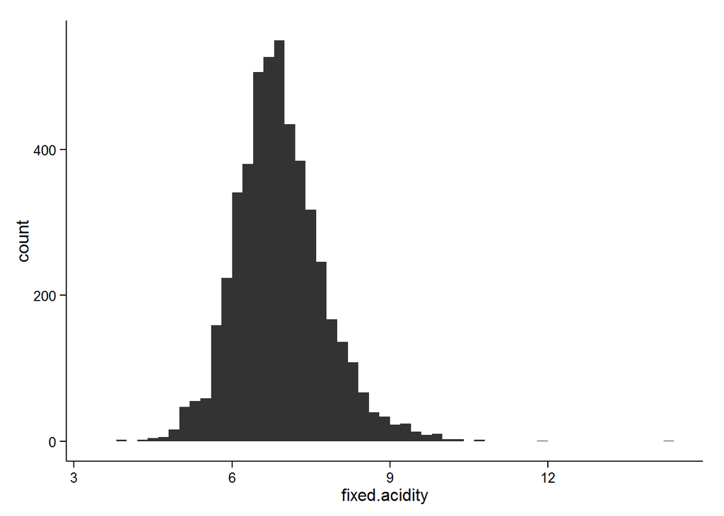

```r
qplot(fixed.acidity, data=wines,binwidth=0.2)
```

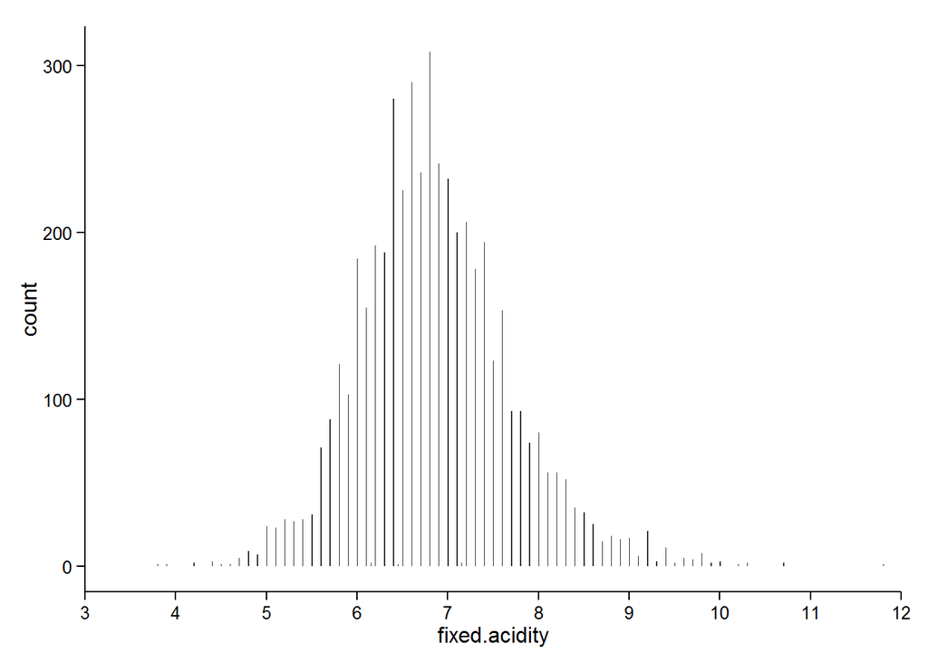

```r
qplot(fixed.acidity, data=wines,binwidth=0.01)+
  coord_cartesian(xlim=c(3,12))+
  scale_x_continuous(breaks=seq(0,12,1))
```

```r
sort(table(wines$fixed.acidity),decreasing=T)
```

```
##
##  6.8  6.6  6.4  6.9  6.7    7  6.5  7.2  7.1  7.4  6.2  6.3    6  7.3  6.1
##  308  290  280  241  236  232  225  206  200  194  192  188  184  178  155
##  7.6  7.5  5.8  5.9  7.7  7.8  5.7    8  7.9  5.6  8.1  8.2  8.3  8.4  8.5
##  153  123  121  103   93   93   88   80   74   71   56   56   52   35   32
##  5.5  5.2  5.4  5.3  8.6    5  5.1  9.2  8.8    9  8.9  8.7  9.4  4.8  9.8
##   31   28   28   27   25   24   23   21   18   17   16   15   11    9    8
##  4.9  9.1  4.7  9.6  9.7  4.4  9.3   10  4.2 6.15 7.15  9.5  9.9 10.3 10.7
##    7    6    5    5    4    3    3    3    2    2    2    2    2    2    2
##  3.8  3.9  4.5  4.6 6.45 10.2 11.8 14.2
##    1    1    1    1    1    1    1    1
```

Fixed acidity seems to be normally distributed over wines, with most values between 6 and 8. Most of the values have a single decimal digit.

#### Volatile acidity

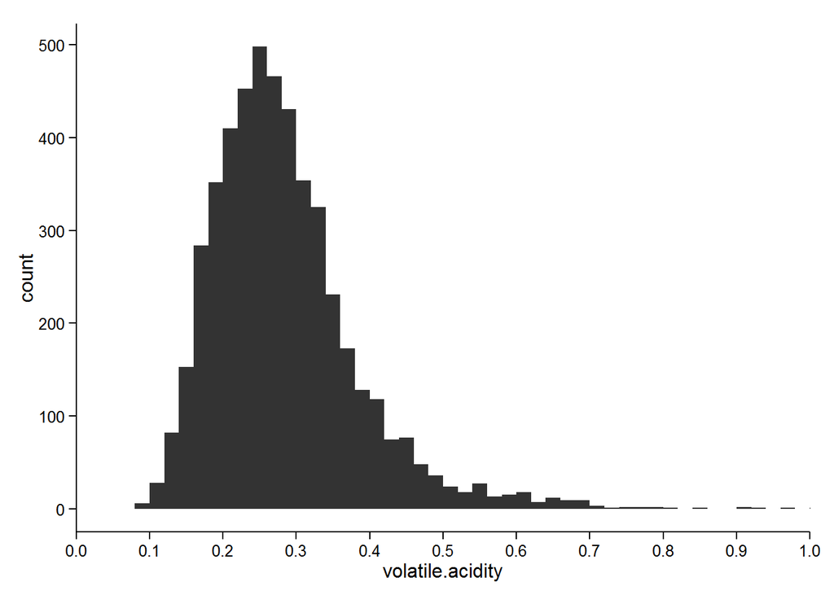

```r
qplot(volatile.acidity, data=wines,binwidth=0.02)+
  coord_cartesian(xlim=c(0,1))+
  scale_x_continuous(breaks=seq(0,1,.1))
```

```r
summary(wines$volatile.acidity)
```

```
##    Min. 1st Qu.  Median    Mean 3rd Qu.    Max.
##  0.0800  0.2100  0.2600  0.2782  0.3200  1.1000
```

Most wines have volatile acidity between 0.2 and 0.35

#### Citric acid

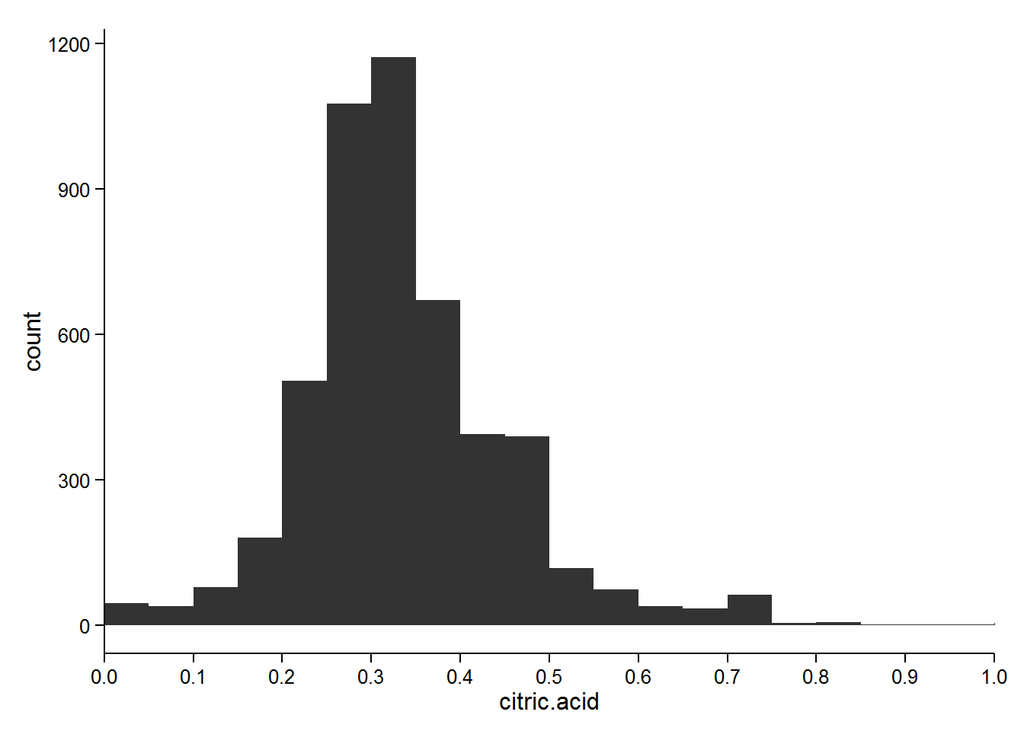

```r
qplot(citric.acid, data=wines,binwidth=0.05)+
  coord_cartesian(xlim=c(0,1))+
  scale_x_continuous(breaks=seq(0,1,.1))
```

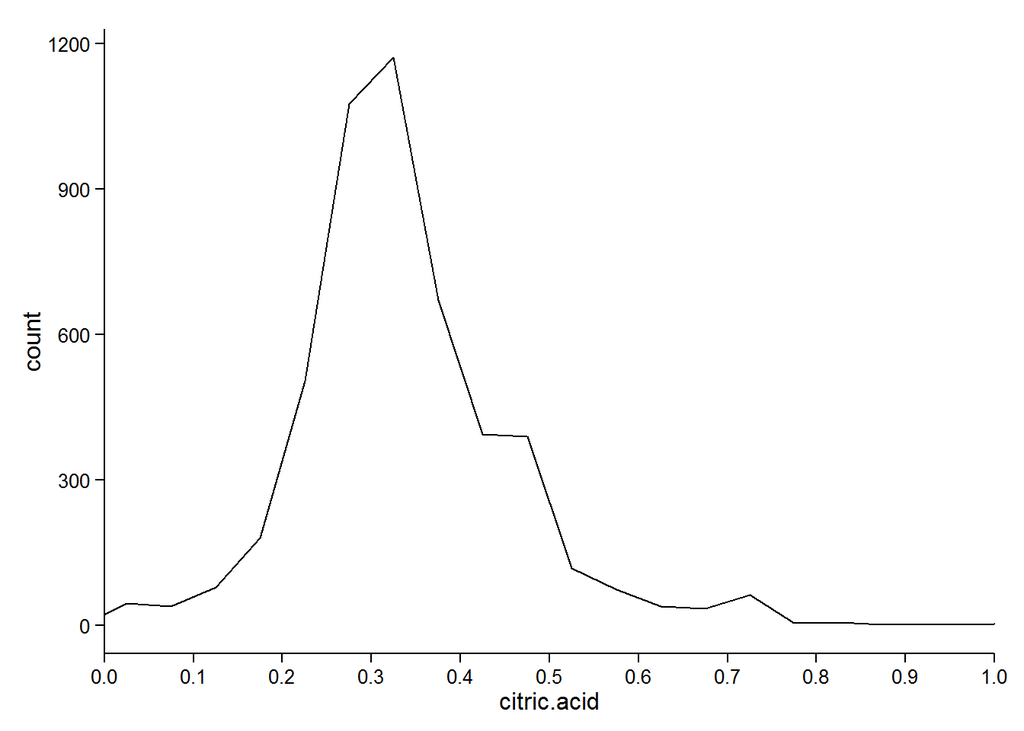

```r
qplot(citric.acid, data=wines,binwidth=0.05, geom = "freqpoly")+
  coord_cartesian(xlim=c(0,1))+
  scale_x_continuous(breaks=seq(0,1,.1))
```

```r
summary(wines$citric.acid)
```

```
##    Min. 1st Qu.  Median    Mean 3rd Qu.    Max.
##  0.0000  0.2700  0.3200  0.3342  0.3900  1.6600
```

Most values of citric acid are between 0.2 and 0.5, with a Median of 0.32. We have wines with no trace of citric acid (Min. :0.0000).

#### Residual sugar

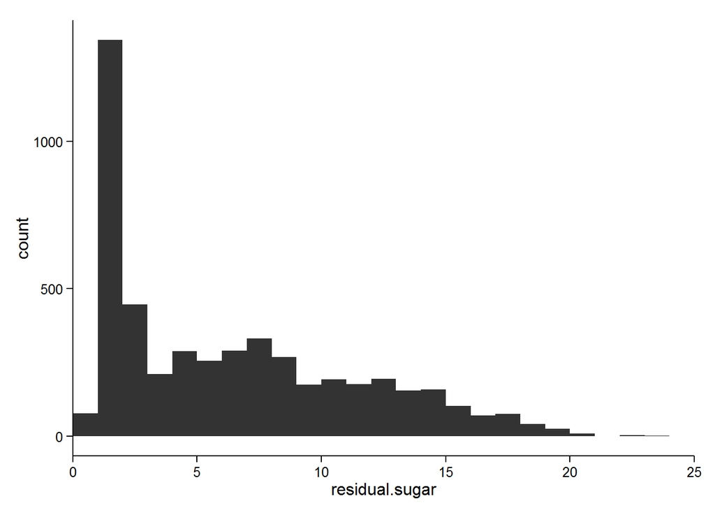

```r
qplot(residual.sugar, data=wines,binwidth=1)+
  coord_cartesian(xlim=c(0,25))
```

```r
summary(wines$residual.sugar)
```

```
##    Min. 1st Qu.  Median    Mean 3rd Qu.    Max.
##   0.600   1.700   5.200   6.391   9.900  65.800
```

There are few wines with residual sugar value less than 1. We then have a peak of values beween 1 and 2, and then the frequency decreases as values grow up to 21. There are some outliers greater than 21.

#### Chlorides

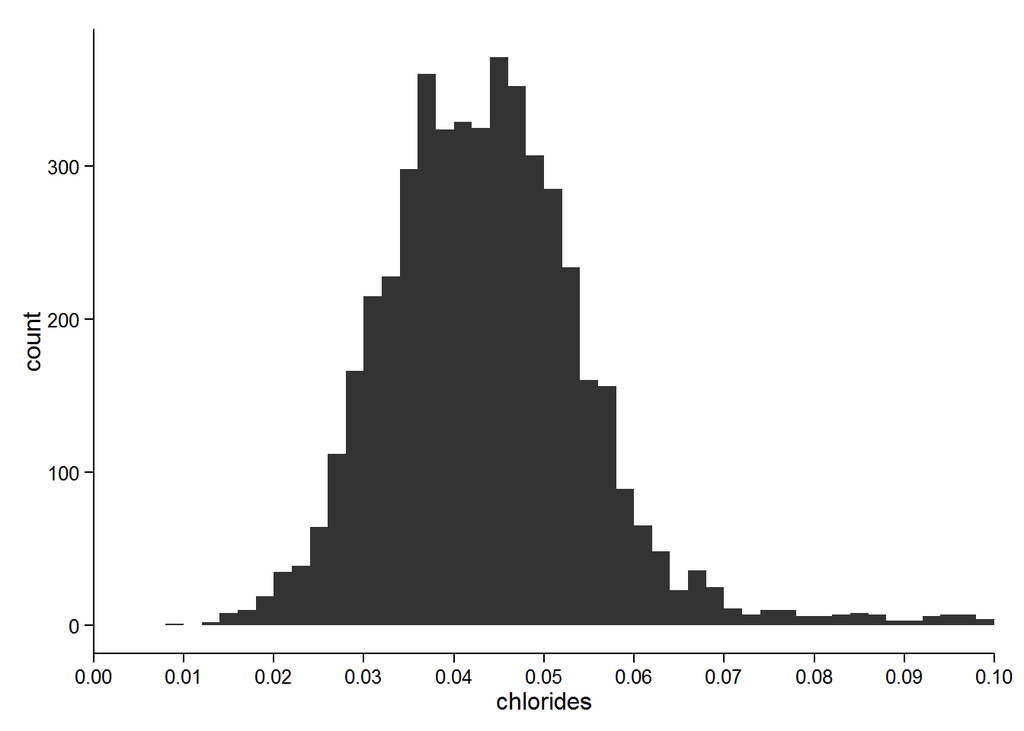

```r
qplot(chlorides, data=wines,binwidth=0.002)+
  coord_cartesian(xlim=c(0,.1))+
  scale_x_continuous(breaks=seq(0,.1,.01))
```

```r
summary(wines$chlorides)
```

```
##    Min. 1st Qu.  Median    Mean 3rd Qu.    Max.
## 0.00900 0.03600 0.04300 0.04577 0.05000 0.34600
```

Chlorides values look like normally distributed with most value between 0.03 and 0.06, and a median of 0.043

#### Free sulfur dioxide

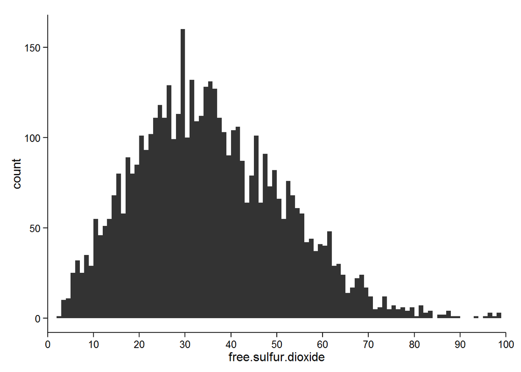

```r
qplot(free.sulfur.dioxide, data=wines,binwidth=1)+
  coord_cartesian(xlim=c(0,100))+
  scale_x_continuous(breaks=seq(0,100,10))
```

```r
sort(table(wines$free.sulfur.dioxide),decreasing=T)
```

```
##
##    29    31    26    35    34    36    24    28    33    25    37    23
##   160   132   129   129   128   127   118   112   112   111   111   110
##    32    41    40    22    38    20    45    27    30    21    47    17
##   109   104   103   102   102   101   101    99    99    93    91    89
##    39    42    19    49    18    15    44    52    14    53    48    46
##    89    86    84    82    80    79    75    72    68    68    66    64
##    50    43    54    16    55    10    13    51    12    61    11    57
##    64    63    61    58    58    55    55    54    51    47    45    44
##    56    59    60    58     8     6    63     9    62     5     7    68
##    42    39    38    37    35    32    30    29    29    25    25    24
##    64    67    66    69    65     4    70     3    73  48.5    75    81
##    23    22    17    17    14    11    11    10     8     7     7     7
##    72    71    74    76    77  44.5  52.5  73.5    78  79.5    83    87
##     6     5     5     5     5     4     4     4     4     4     4     4
##    96    98   108  35.5  41.5  50.5  59.5  60.5    79    82    85    86
##     3     3     3     2     2     2     2     2     2     2     2     2
##   101   105     2  11.5  15.5  19.5  23.5  28.5  30.5  38.5  39.5  40.5
##     2     2     1     1     1     1     1     1     1     1     1     1
##  42.5  43.5  51.5  61.5  64.5  70.5  77.5    80  82.5    88    89    93
##     1     1     1     1     1     1     1     1     1     1     1     1
##    95    97   110   112 118.5 122.5   124   128   131 138.5 146.5   289
##     1     1     1     1     1     1     1     1     1     1     1     1
```

```r
summary(wines$free.sulfur.dioxide)
```

```
##    Min. 1st Qu.  Median    Mean 3rd Qu.    Max.
##    2.00   23.00   34.00   35.31   46.00  289.00
```

Distribution of Free sulfur dioxide also looks normal, with more values between 20 and 50. Also, most values are integers, non-integer values count starting from 7 down.

#### Density

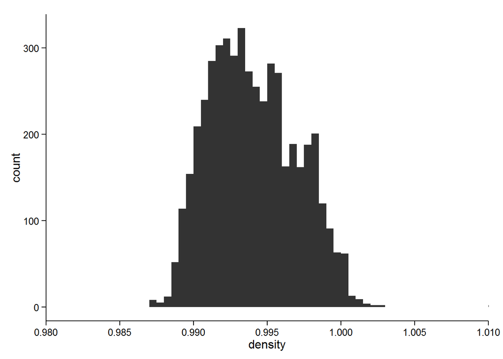

```r
qplot(density, data=wines,binwidth=0.0005)+
  coord_cartesian(xlim=c(0.98,1.01))+
  scale_x_continuous(breaks=seq(0.98,1.01,.005))
```

```r
summary(wines$density)
```

```
##    Min. 1st Qu.  Median    Mean 3rd Qu.    Max.
##  0.9871  0.9917  0.9937  0.9940  0.9961  1.0390
```

Density values are very compact and ranges most between 0.99 and 1

#### pH

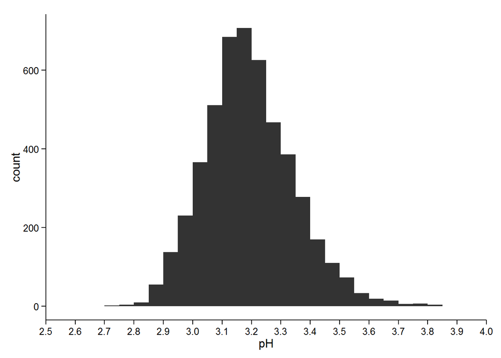

```r
qplot(pH, data=wines,binwidth=0.05)+
  coord_cartesian(xlim=c(2.5,4))+
  scale_x_continuous(breaks=seq(2.5,4,0.1))
```

```r
summary(wines$pH)
```

```
##    Min. 1st Qu.  Median    Mean 3rd Qu.    Max.
##   2.720   3.090   3.180   3.188   3.280   3.820
```

Most wines have pH between 3 and 3.4, with the median at 3.18

#### Sulphates

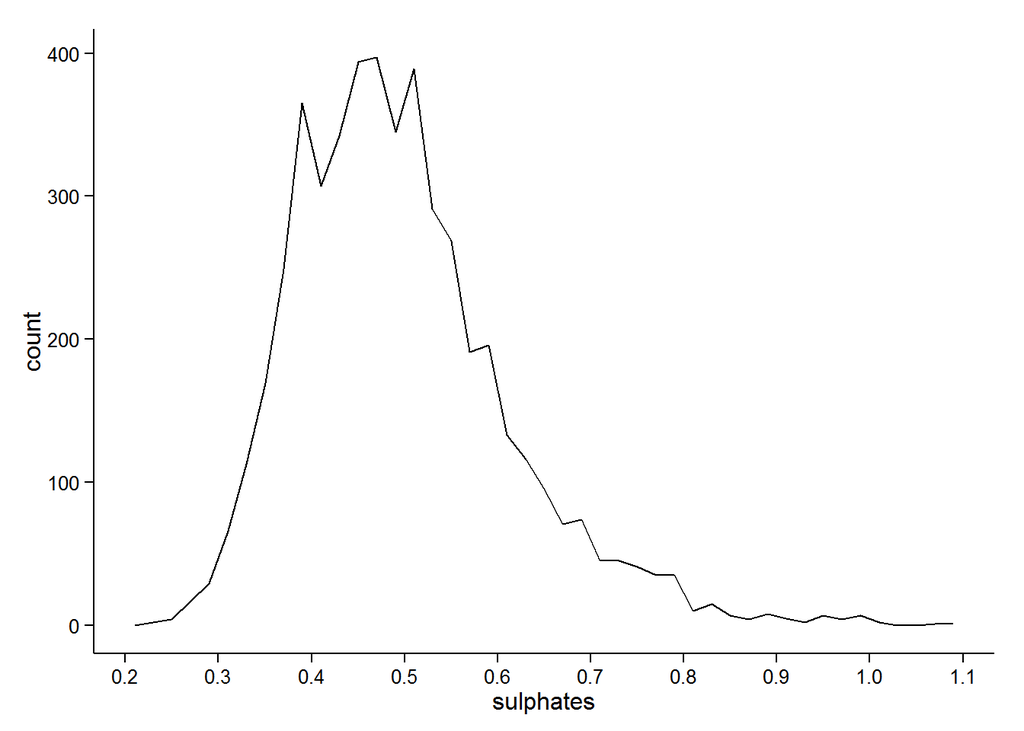

```r
qplot(sulphates, data=wines,binwidth=.02,geom = "freqpoly")+
  scale_x_continuous(breaks=seq(0.2,1.1,0.1))
```

```r
summary(wines$sulphates)
```

```
##    Min. 1st Qu.  Median    Mean 3rd Qu.    Max.
##  0.2200  0.4100  0.4700  0.4898  0.5500  1.0800
```

Most wines have sulphates between 0.35 and 0.6. The median is 0.47 and the mean 0.49

#### Alcohol

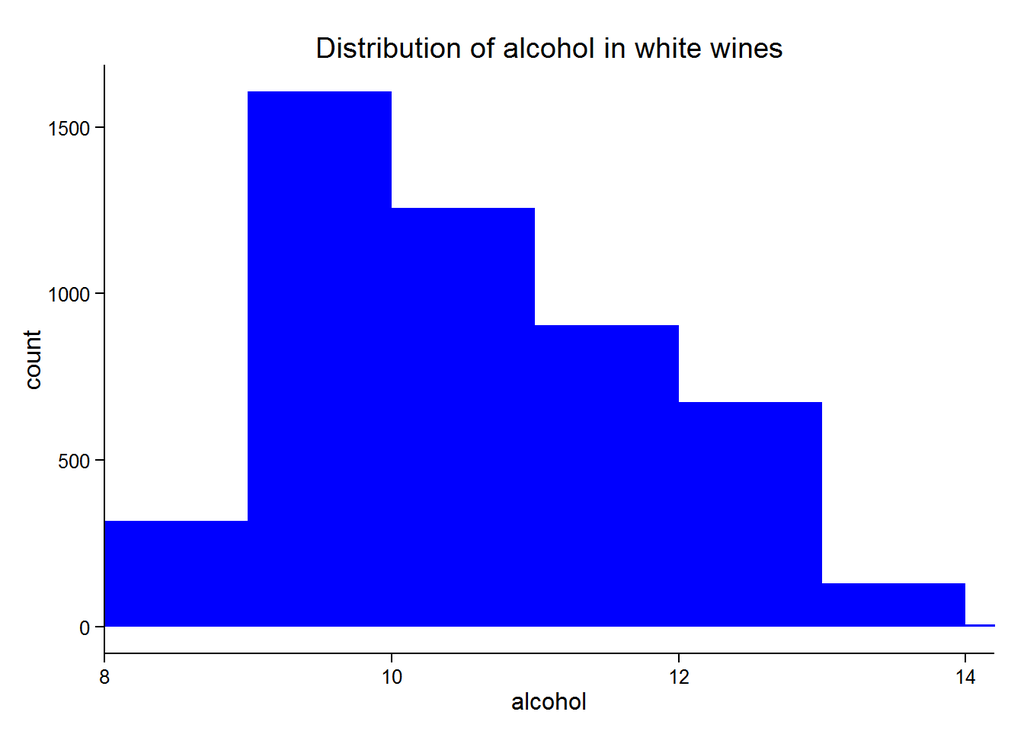

```r
alcohol.plot=qplot(alcohol, data=wines,binwidth=1,fill=I('blue')
                   ,main="Distribution of alcohol in white wines")+
  coord_cartesian(xlim=c(8,14.20))

alcohol.plot
```

```r
summary(wines$alcohol)
```

```
##    Min. 1st Qu.  Median    Mean 3rd Qu.    Max.
##    8.00    9.50   10.40   10.51   11.40   14.20
```

We have few wines with alcohol rate between 8 and 9. The peak of frequency is betwhen 9 an 10. The frequency then decreases with alcohol growing up to 14. Most values are between 9 and 12.

#### Quality

```
## stat_bin: binwidth defaulted to range/30. Use 'binwidth = x' to adjust this.
```

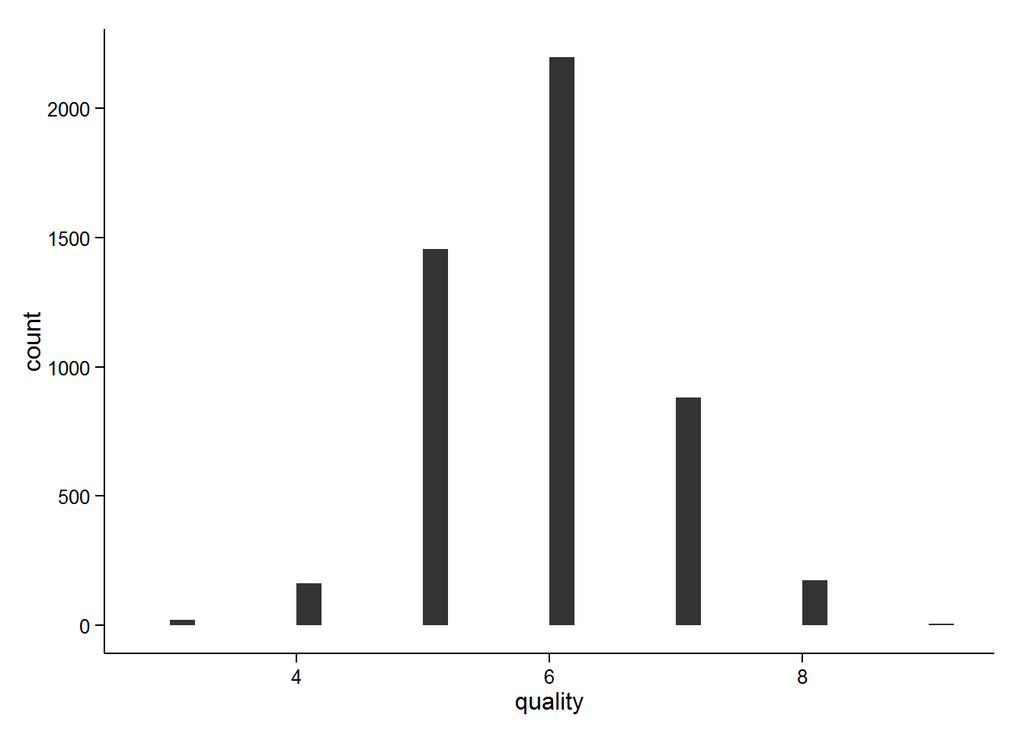

```r
qplot(quality, data=wines, geom='bar')
```

```r
sort(table(wines$quality),decreasing=T)
```

```
##
##    6    5    7    8    4    3    9
## 2198 1457  880  175  163   20    5
```

```r
summary(wines$quality)
```

```
##    Min. 1st Qu.  Median    Mean 3rd Qu.    Max.
##   3.000   5.000   6.000   5.878   6.000   9.000
```

Wines quality ranges from 3 to 9. Most them are between 5, 6 and 7, the Median is 6.

#### First take off

Most of the variables(excepting residual sugar, alcohol and quality) seems to be normally distributed! What could be the relationships between them?

### Examining the relationships between any two variables?

#### Plotting all pairs

First of all, let us get an overview of how any pair of variables can be related

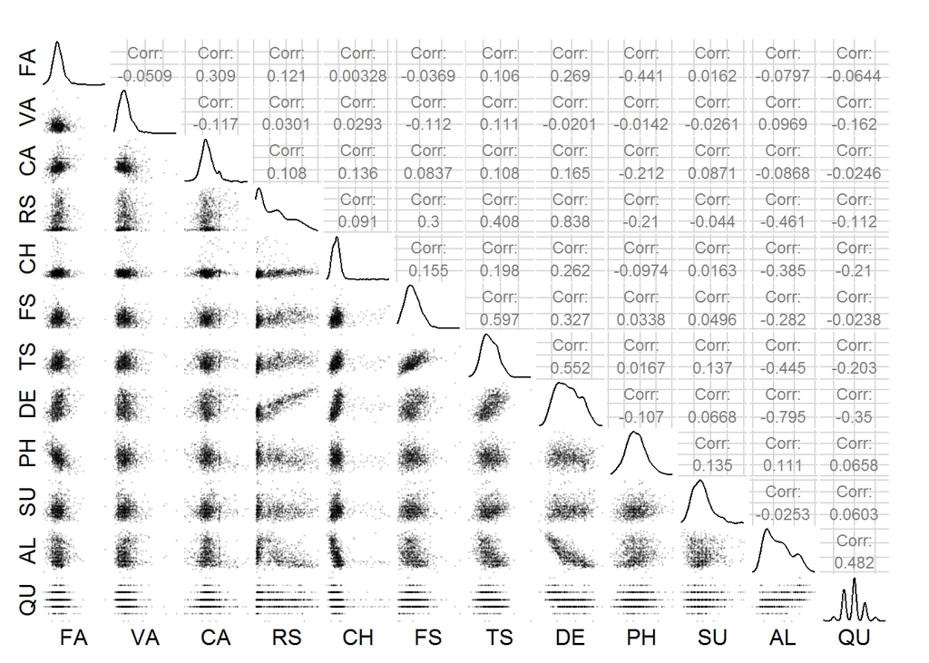

```r
set.seed(2500)
ggpairs(wines[sample.int(nrow(wines),1000),] ,axisLabels='none',
        upper=list(params=list(size=3)),
        lower=list(params=list(size=I(.5),alpha=I(.2))),
        columnLabels=c('FA','VA','CA','RS','CH','FS','TS',
                       'DE','PH','SU','AL','QU'))
```

I will first go deeper in the plots that looks linear (Residual sugar vs Density, alcohol vs density). I am also interrested by looking deeper in some other relationships like fixed acidity vs residual sugar and citric acid vs residual sugar. I will end by exploring the relationships between quality and any other variable

#### Density vs Residual sugar

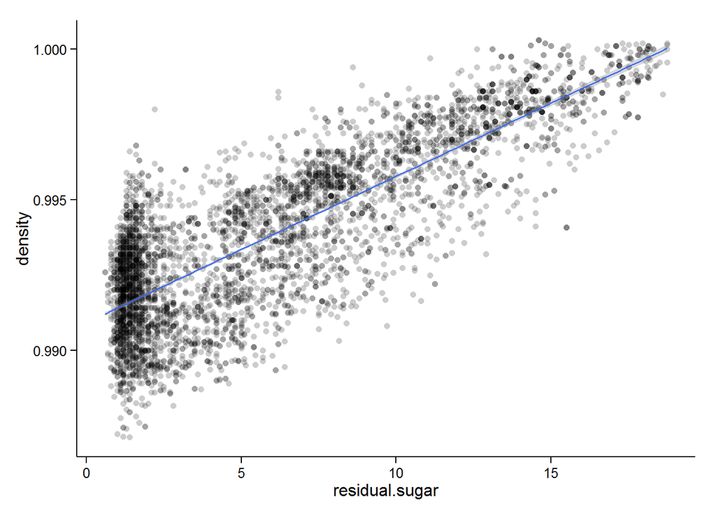

```r
qplot(x=residual.sugar,y=density,
      data=subset(wines,
                  residual.sugar<quantile(wines$residual.sugar,.99) &
                    density<quantile(density,.99)),
      alpha=I(.2))+geom_smooth(method='lm')
```

```r
cor.test(wines$residual.sugar,wines$density)
```

```
##
##  Pearson's product-moment correlation
##
## data:  wines$residual.sugar and wines$density
## t = 107.8749, df = 4896, p-value < 2.2e-16
## alternative hypothesis: true correlation is not equal to 0
## 95 percent confidence interval:
##  0.8304732 0.8470698
## sample estimates:
##       cor
## 0.8389665
```

Plotting them together and also computing the correlation shoes that density and residual sugar are highly correlated, they will not be used together if we produced a model.

#### Density vs Alcohol

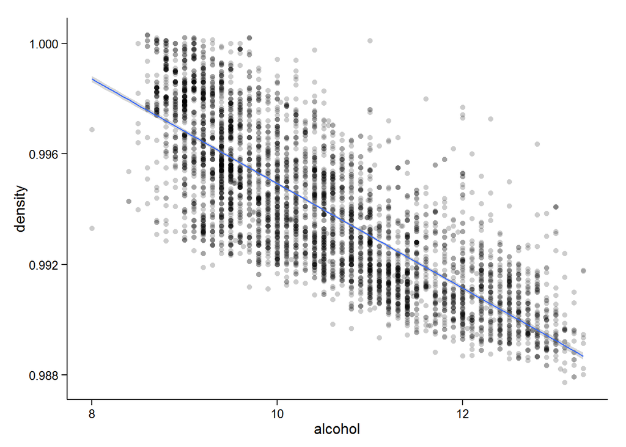

```r
qplot(x=alcohol,y=density,
      data=subset(wines,alcohol<quantile(wines$alcohol,.99) &
                    density<quantile(density,.99)),
      alpha=I(.2))+
  geom_smooth(method='lm')
```

```r
cor.test(wines$alcohol,wines$density)
```

```
##
##  Pearson's product-moment correlation
##
## data:  wines$alcohol and wines$density
## t = -87.2549, df = 4896, p-value < 2.2e-16
## alternative hypothesis: true correlation is not equal to 0
## 95 percent confidence interval:
##  -0.7908646 -0.7689315
## sample estimates:
##        cor
## -0.7801376
```

Again we can see a strong correlation between the two variables, even if our linear model is decreasing in this case. What about alcohol and residual sugar?

#### Residual sugar vs Alcohol

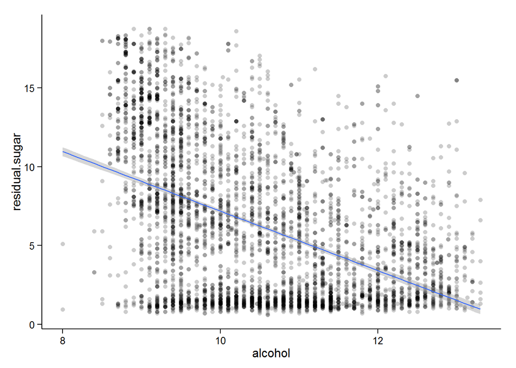

```r
qplot(x=alcohol,y=residual.sugar,
      data=subset(wines,alcohol<quantile(wines$alcohol,.99) &
                    residual.sugar<quantile(residual.sugar,.99)),
      alpha=I(.2))+
  geom_smooth(method='lm')
```

```r
cor.test(wines$alcohol,wines$residual.sugar)
```

```
##
##  Pearson's product-moment correlation
##
## data:  wines$alcohol and wines$residual.sugar
## t = -35.3209, df = 4896, p-value < 2.2e-16
## alternative hypothesis: true correlation is not equal to 0
## 95 percent confidence interval:
##  -0.4726723 -0.4280267
## sample estimates:
##        cor
## -0.4506312
```

#### Fixed acidity vs Residual sugar

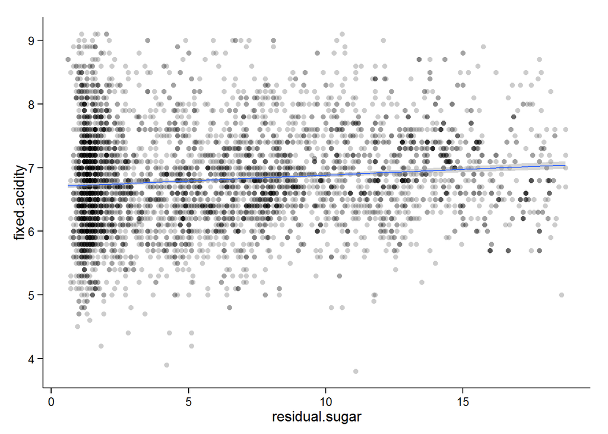

```r
qplot(x=residual.sugar,y=fixed.acidity,
      data=subset(wines,
                  residual.sugar<quantile(wines$residual.sugar,.99) &
                    fixed.acidity<quantile(fixed.acidity,.99)),
      alpha=I(.2))+
  geom_smooth(method='lm')
```

```r
cor.test(wines$residual.sugar,wines$fixed.acidity)
```

```
##
##  Pearson's product-moment correlation
##
## data:  wines$residual.sugar and wines$fixed.acidity
## t = 6.2537, df = 4896, p-value = 4.348e-10
## alternative hypothesis: true correlation is not equal to 0
## 95 percent confidence interval:
##  0.06116674 0.11673612
## sample estimates:
##       cor
## 0.0890207
```

The avreage fixed acidity value is almost the same for different residual sugar values

#### Residual sugar vs Citric acid

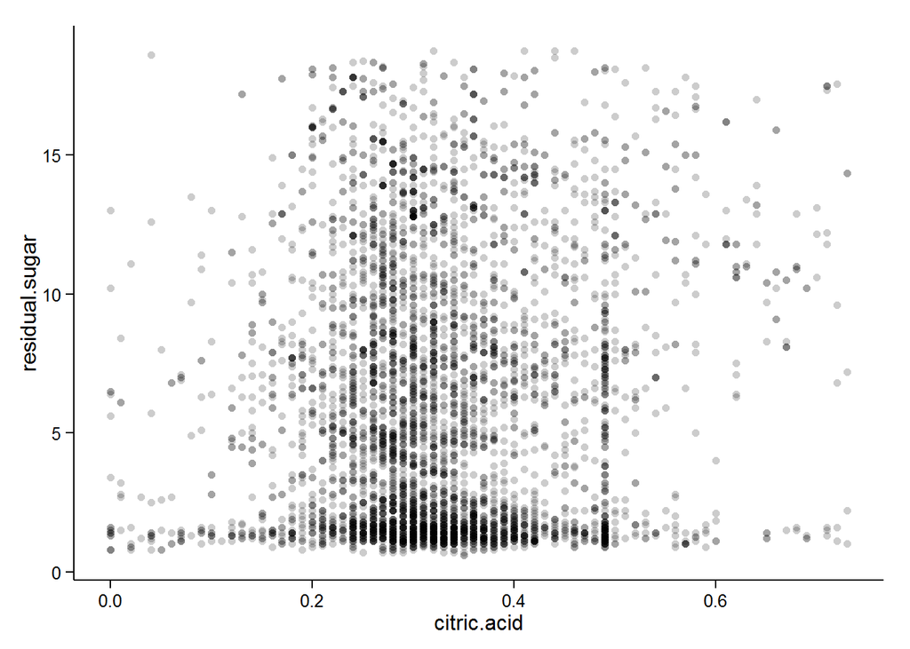

```r
qplot(x=citric.acid,y=residual.sugar,
      data=subset(wines,
                  residual.sugar<quantile(wines$residual.sugar,.99) &
                    citric.acid<quantile(citric.acid,.99)),
      alpha=I(.2))
```

Again, difficult to see any relationship between the two variables

Let us see how any of the attributes relates to wine quality

#### Quality vs Fixed.acidity

```
## geom_smooth: method="auto" and size of largest group is >=1000, so using gam with formula: y ~ s(x, bs = "cs"). Use 'method = x' to change the smoothing method.
```

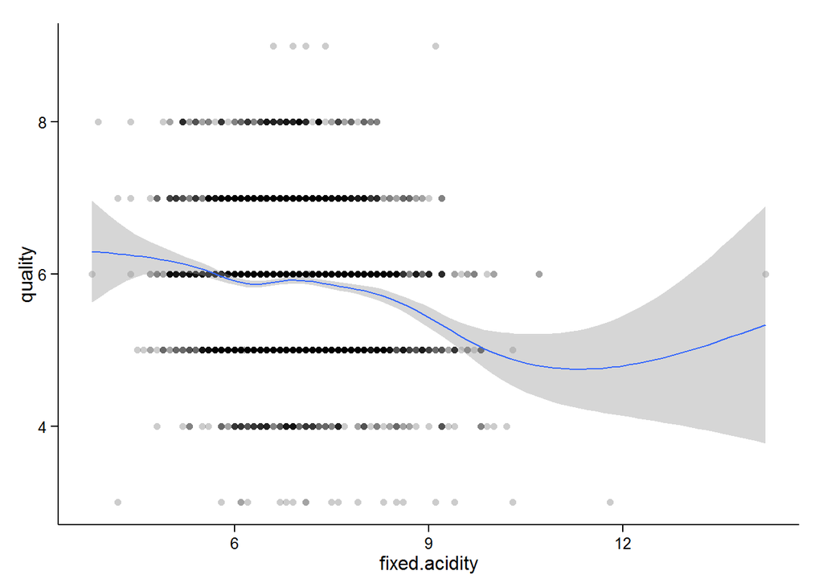

```r
fixed.acidity.plot=qplot(x=fixed.acidity, y=quality,
                         data=wines, alpha=I(.2))+
  geom_smooth()

fixed.acidity.plot
```

It might be difficult to see this just by looking at the scatter plot, but adding the smoothed conditional mean shows us that average quality tends to decrease when fixed acidity increases.

Let us do a similar plots for quality and others attributes

#### Quality vs other attributes

```r
plots=list()
nameList=names(wines)
labelList=c('Fixed acidity','Volatile acidity','Citric acid',
            'Residual sugar','Chlorides','Free sulfur dioxide',
            'Total sulfur dioxide','Density',
               'pH','Sulphates','Alcohol')
len=length(labelList)
# add a plot for each variable
for ( i in 1:len){
  name=nameList[i]
  # exclude outliers from plots
  quant=quantile(wines[,name],.99)
  plots[[i]]=ggplot(aes_string(x=name, y='quality'),
                    data=wines[wines[,name]<=quant,])+
    geom_point(alpha=I(.1),size=I(.2),color=I('orange'))+
    geom_smooth()+
    ylab("Quality")+
    xlab(labelList[i])
}
#got this on stackovervlow
quality.others.plot=do.call(arrangeGrob,c(plots,ncol=4,
                            main="Quality vs other attributes"))
```

[output not shown]

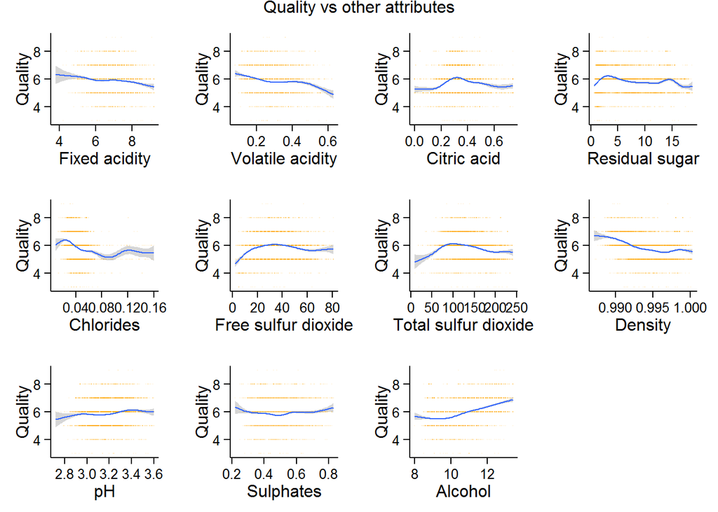

```r
quality.others.plot
```

Wine quality seems to increase with alcohool and pH, and decrease with fixed acidity, volatile acidity and density.It is more difficult to appreciate for other attributes. Let us see how it may relate to two or more of these variables.

### Analyzing three or more variables

#### Wine quality vs alcohol and fixed acidity

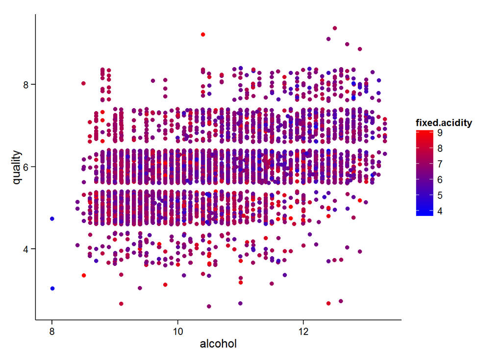

```r
qplot(x=alcohol,y=quality,color=fixed.acidity,
      data=subset(wines,alcohol<quantile(wines$alcohol,.99)&
                    fixed.acidity<quantile(fixed.acidity,.99)),
      geom='jitter')+
  scale_color_gradientn(colours =
                          colorRampPalette(c("blue", "red"))(100))
```

Difficult to take anything from this heat map. Let us separate fixed acidity and volatile acidity into two buckets first and plot again

```r
#divide a vector in thwo buckets around the median
cutInTwo=function(vector){
  return(cut(vector,breaks=c(floor(min(vector)),median(vector),
                             ceiling((max(vector))))))
}

wines$fixed.acidity.bucket=cutInTwo(wines$fixed.acidity)

#other buckets to be used later in the analysis
wines$volatile.acidity.bucket=cutInTwo(wines$volatile.acidity)

wines$pH.bucket=cutInTwo(wines$pH)
```

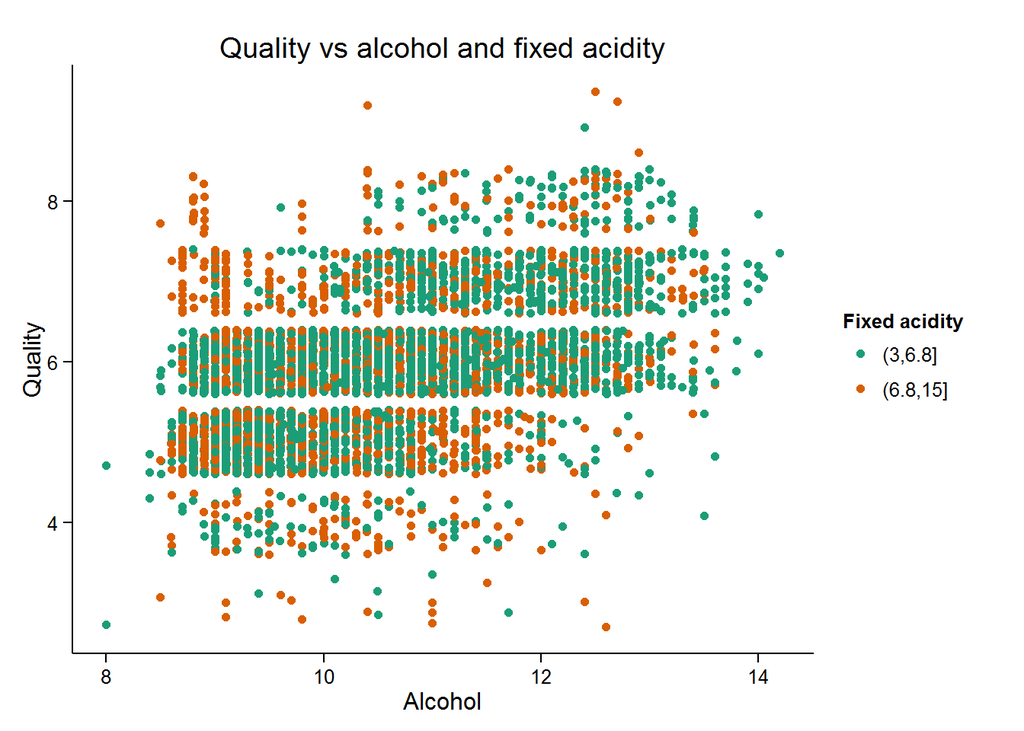

```r
title="Quality vs alcohol and fixed acidity"
quality.alcohol.fixed.acidity.plot=qplot(x=alcohol,y=quality,
                                         color=fixed.acidity.bucket,
                                         geom='jitter',
                                         data=wines,xlab="Alcohol",
                                         ylab="Quality",
                                         main=title)+
  scale_color_brewer(type='qual',palette=2,
                     guide=guide_legend(title="Fixed acidity"))



quality.alcohol.fixed.acidity.plot
```

Now you can see that for lower values of alcohool(alcohol< 10), better quality wines have higher fixed acidity whereas better quality wines have lower fixed acidity for wines with higher values of alcohol.

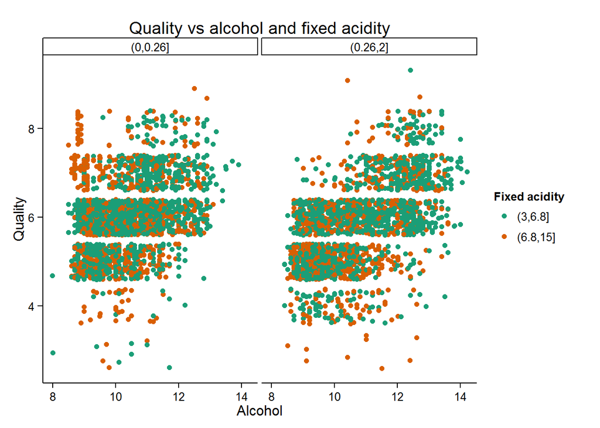

```r
quality.alcohol.fixed.acidity.plot+
  facet_wrap(~volatile.acidity.bucket)
```

The pattern observed on the previous plot seems to be kept for differents buckets of volatile acidity

```
## geom_smooth: method="auto" and size of largest group is >=1000, so using gam with formula: y ~ s(x, bs = "cs"). Use 'method = x' to change the smoothing method.
## geom_smooth: method="auto" and size of largest group is >=1000, so using gam with formula: y ~ s(x, bs = "cs"). Use 'method = x' to change the smoothing method.
```

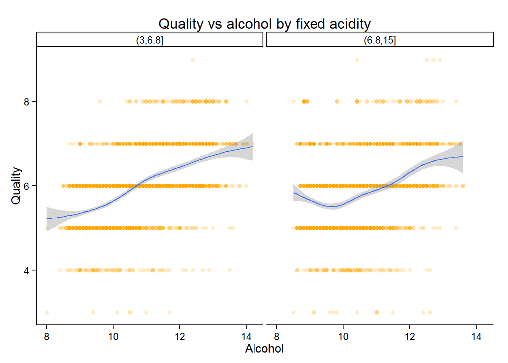

```r
quality.alcohol.plot=qplot(x=alcohol, y=quality, data=wines,
                           alpha=I(.2), color=I("Orange"),
                           xlab='Alcohol',ylab="Quality")+
  geom_smooth()

quality.alcohol.by.fixed.acidity.plot=quality.alcohol.plot+
  facet_wrap(~fixed.acidity.bucket)+
  ggtitle("Quality vs alcohol by fixed acidity")


quality.alcohol.by.fixed.acidity.plot
```

The increase of wine quality with alcohol seems more evident for lower values of fixed acidity than for higher ones

#### Wine quality vs alcohol and volatile acidity

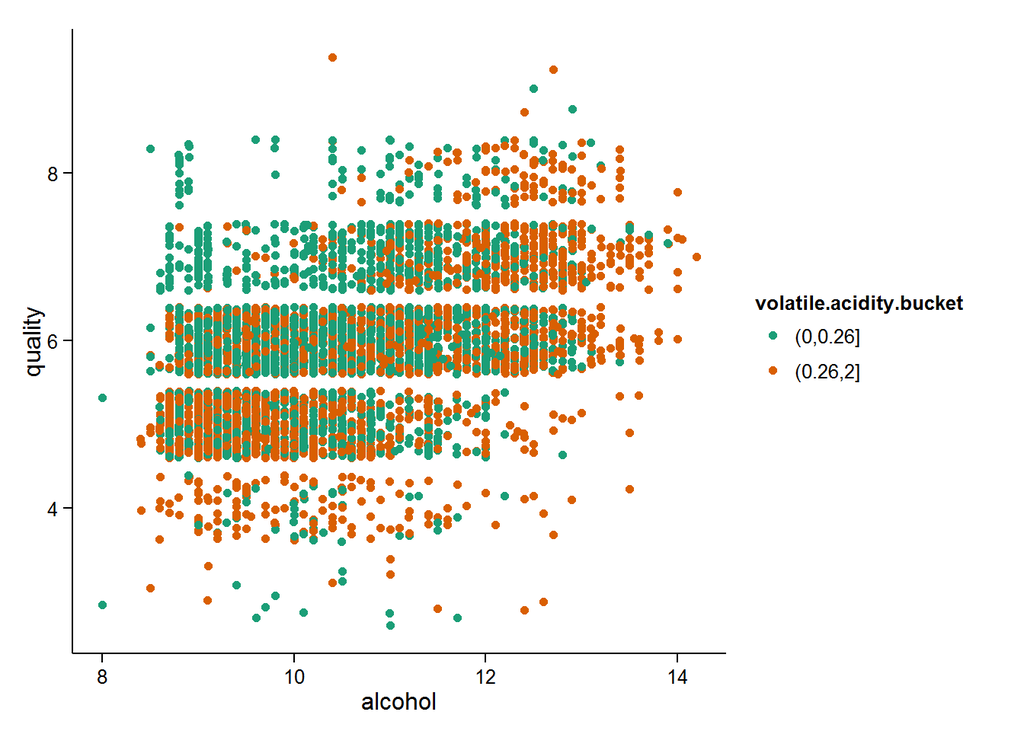

```r
quality.alcohol.volatile.acidity.plot=
  qplot(x=alcohol,y=quality,
        color=volatile.acidity.bucket,
        geom='jitter',data=wines)+
  scale_color_brewer(type='qual',palette=2)

quality.alcohol.volatile.acidity.plot
```

Holding alcohol constant, wines with lower volatile acidity seeems to have higher quality. This is more visible for wines with alcohol value lower than 12.

```
## geom_smooth: method="auto" and size of largest group is >=1000, so using gam with formula: y ~ s(x, bs = "cs"). Use 'method = x' to change the smoothing method.
## geom_smooth: method="auto" and size of largest group is >=1000, so using gam with formula: y ~ s(x, bs = "cs"). Use 'method = x' to change the smoothing method.
```

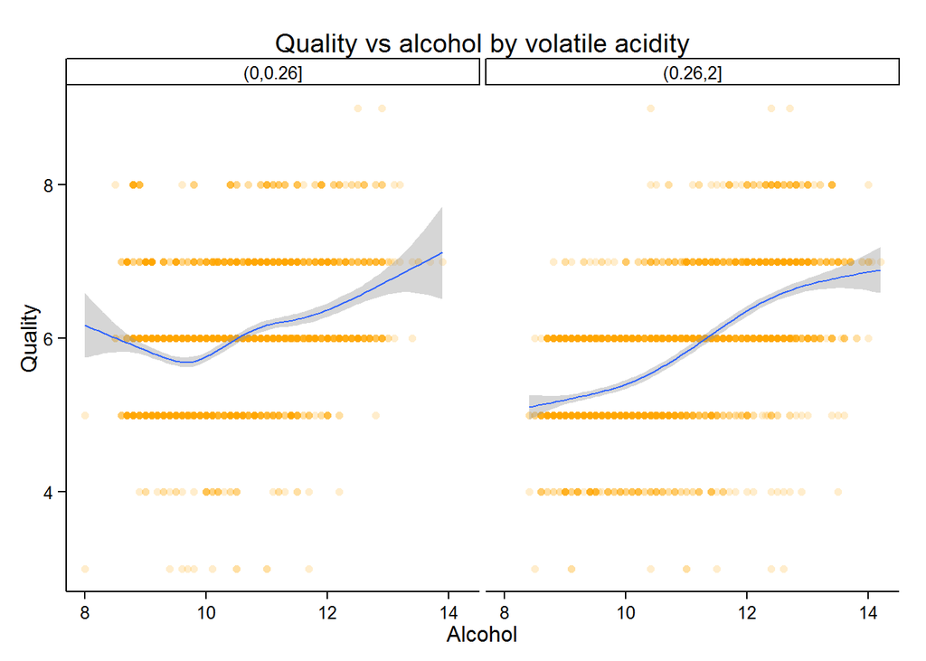

```r
quality.alcohol.by.volatile.acidity.plot=
  quality.alcohol.plot+
  facet_wrap(~volatile.acidity.bucket)+
  ggtitle("Quality vs alcohol by volatile acidity")

quality.alcohol.by.volatile.acidity.plot
```

The increase of wine quality with alcohol seems more evident for higher values of volatile acidity than for lower ones

#### Wine quality vs density and fixed acidity

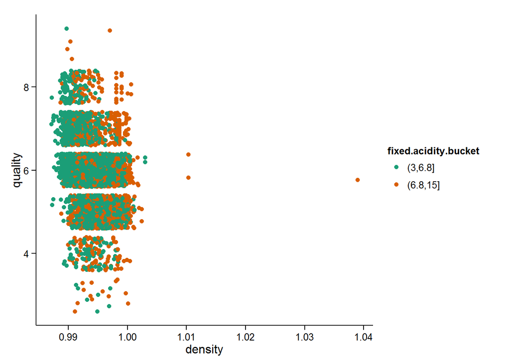

```r
quality.density.fixed.acidity.plot=
  qplot(x=density,y=quality,
       color=fixed.acidity.bucket,
       geom='jitter',data=wines)+
  scale_color_brewer(type='qual',palette=2)

quality.density.fixed.acidity.plot
```

Let us remove outliers an plot again

```r
wines.density.99=subset(wines,
                        wines$density<quantile(wines$density,.99))
```

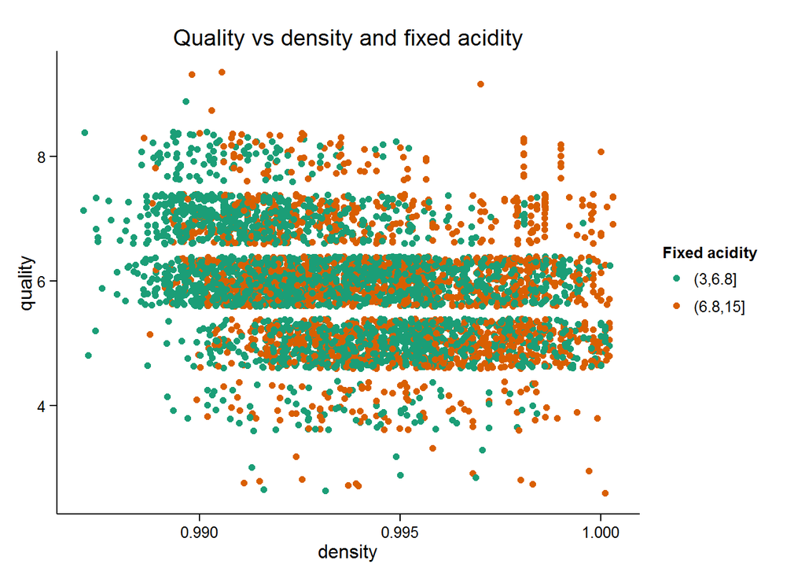

```r
title="Quality vs density and fixed acidity"
quality.density.fixed.acidity.plot=qplot(x=density,y=quality,
                                         color=fixed.acidity.bucket,
                                         geom='jitter',
                                         data=wines.density.99,
                                         main=title)+
  scale_color_brewer(type='qual',palette=2,
                     guide=guide_legend(title="Fixed acidity"))

quality.density.fixed.acidity.plot
```

For higher values of density, wines of better quality have higher fixed acidity. It is consistent with what we observed for alcohol since it is highly correlated with density but having a negative correlation coefficient.

```
## geom_smooth: method="auto" and size of largest group is >=1000, so using gam with formula: y ~ s(x, bs = "cs"). Use 'method = x' to change the smoothing method.
## geom_smooth: method="auto" and size of largest group is >=1000, so using gam with formula: y ~ s(x, bs = "cs"). Use 'method = x' to change the smoothing method.
```

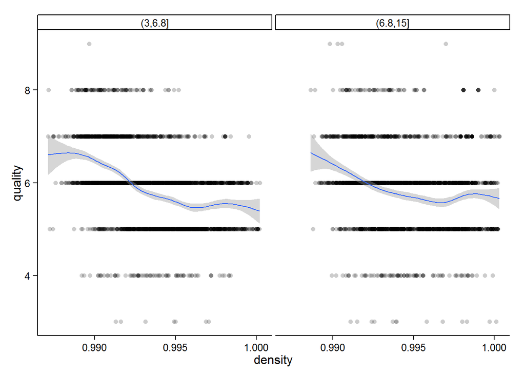

```r
quality.density.plot=qplot(x=density, y=quality,
                           data=wines.density.99, alpha=I(.2))+
  geom_smooth()

quality.density.plot+
  facet_wrap(~fixed.acidity.bucket)
```

The decrease of wine quality with density is visible for both higher and lower values of fixed acidity.

#### Wine quality vs density and volatile acidity

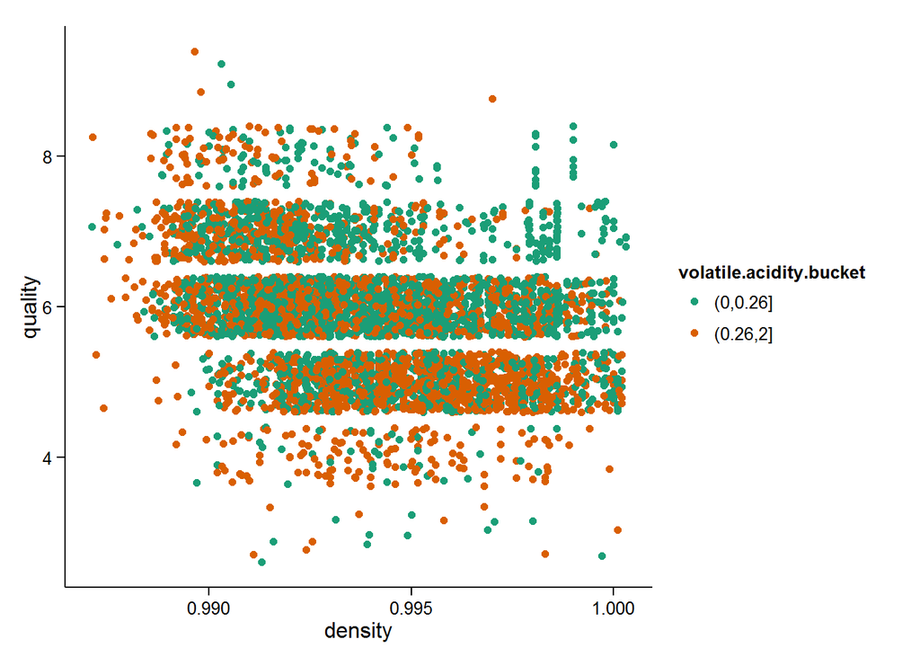

```r
quality.density.volatile.acidity.plot=
  qplot(x=density,y=quality,
        color=volatile.acidity.bucket,
        geom='jitter',data=wines.density.99)+
  scale_color_brewer(type='qual',palette=2)

quality.density.volatile.acidity.plot
```

For higher values of density, wines of better quality have lower volatile acidity.

```
## geom_smooth: method="auto" and size of largest group is >=1000, so using gam with formula: y ~ s(x, bs = "cs"). Use 'method = x' to change the smoothing method.
## geom_smooth: method="auto" and size of largest group is >=1000, so using gam with formula: y ~ s(x, bs = "cs"). Use 'method = x' to change the smoothing method.
```

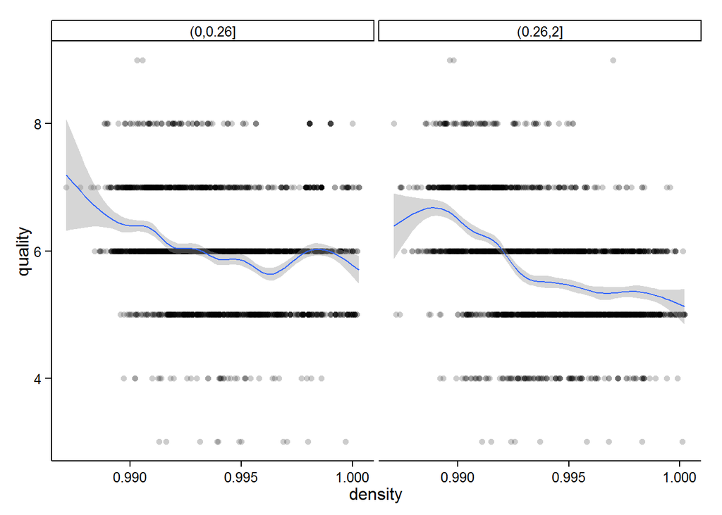

```r
quality.density.plot+
  facet_wrap(~volatile.acidity.bucket)
```

For both higher and lower values of volatile acidity, wine quality globally decreases with density